# Statistical Analysis

Zhiqiang Pang, Jasmine Chong, Jeff Xia

2023-07-24

## 1. Introduction

MetaboAnalystR, in parallel with the webserver, provides a comprehensive suite of statistical analyses to perform on a user-uploaded data set. While researchers may have several goals for their metabolomics data, the ultimate goal is to identify any significant metabolite/s indicitive of a disease state, drugs, diet, environment, geographical location, etc.

The standard workflow for statistical analysis is as follows:

**Processed metabolomic data -> Univariate analysis -> Multivariate analysis -> Biological interpretation**

Univariate tests differ from multivariate tests in that they assess the importance of each variable seperately. Meanwhile, multivariate tests assess two or more variables at once, while also taking into consideration the relationship between the variables. Finally, biological interpretation provides a biological context for the significant metabolites identified using univariate/multivariate methods. Below, we will discuss the various statistical methods in greater detail. For the tutorial, we will be using a dataset consisting of concentrations of 77 urine samples from cancer patients (cachexic vs. control) measured by 1H NMR - [Eisner et al. 2010](https://link.springer.com/article/10.1007%2Fs11306-010-0232-9).

## 2. Univariate Methods

To begin the SA module, we will start with identifying important features from the data set using various univariate tests, including classical methods such as the Student’s t-test and ANOVA, as well as other methods such as the volcano plot and correlation analysis.

```r
# Load MetaboAnalystR
library(MetaboAnalystR)

# Clean global environment
rm(list = ls())
```

```r
library(MetaboAnalystR)
mSet<-InitDataObjects("conc", "stat", FALSE);
```

```
## Starting Rserve:
##  /opt/R/4.2.2/lib/R/bin/R CMD /opt/R/4.2.2/lib/R/library/Rserve/libs//Rserve --no-save
##
## [1] "MetaboAnalyst R objects initialized ..."
```

```r
mSet<-Read.TextData(mSet, "https://www.xialab.ca/api/download/metaboanalyst/human_cachexia.csv", "rowu", "disc");
mSet<-SanityCheckData(mSet);
```

```
##  [1] "Successfully passed sanity check!"
##  [2] "Samples are not paired."
##  [3] "2 groups were detected in samples."
##  [4] "Only English letters, numbers, underscore, hyphen and forward slash (/) are allowed."
##  [5] "<font color=\"orange\">Other special characters or punctuations (if any) will be stripped off.</font>"
##  [6] "All data values are numeric."
##  [7] "A total of 0 (0%) missing values were detected."
##  [8] "<u>By default, missing values will be replaced by 1/5 of min positive values of their corresponding variables</u>"
##  [9] "Click the <b>Proceed</b> button if you accept the default practice;"
## [10] "Or click the <b>Missing Values</b> button to use other methods."
```

```r
mSet<-ReplaceMin(mSet);
mSet<-PreparePrenormData(mSet);
mSet<-Normalization(mSet, "NULL", "LogNorm", "MeanCenter", "S10T0", ratio=FALSE, ratioNum=20);
```

```
## [1] 77 63
```

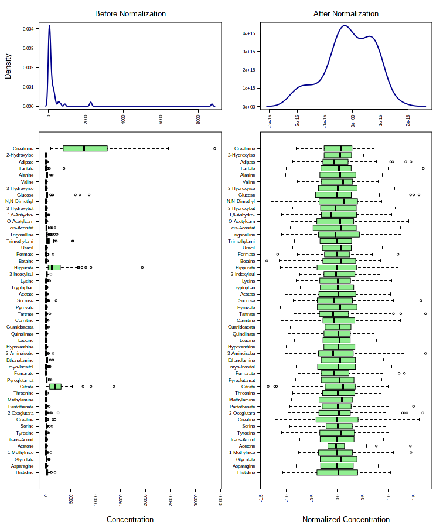

Figure 1. Normalization results.

```r
mSet<-PlotNormSummary(mSet, "norm_0_", format ="png", dpi=72, width=NA);
mSet<-PlotSampleNormSummary(mSet, "snorm_0_", format = "png", dpi=72, width=NA);
```

### 2.1 Fold-change analysis

The goal of fold-change (FC) analysis is to compare the absolute value of change between two group means. Since column-wise normalization (i.e. log transformation, mean-centering) will significantly alter absolute values, FC is calculated as the ratio between two group means using the data before column-wise normalization was applied.

For paired analysis, the program first counts the number of pairs with consistent change above the given FC threshold. If this number exceeds a given count threshold, the variable will be reported as significant.

```
## 1,6-Anhydro-beta-D-glucose       1-Methylnicotinamide
##                   0.888690                  -0.052019
##            2-Aminobutyrate       2-Hydroxyisobutyrate
##                   1.312700                   0.633520
##             2-Oxoglutarate         3-Aminoisobutyrate
##                   1.098400                   1.329100
##          3-Hydroxybutyrate       3-Hydroxyisovalerate
##                   1.563700                   1.164900
##           3-Indoxylsulfate     4-Hydroxyphenylacetate
##                   0.857170                   0.263810
##                    Acetate                    Acetone
##                   1.266100                   0.664560
##                    Adipate                    Alanine
##                   1.952900                   1.141300
##                 Asparagine                    Betaine
##                   0.852650                   1.004000
##                  Carnitine                    Citrate
##                   0.994090                   0.883620
##                   Creatine                 Creatinine
##                   1.763900                   0.932160
##              Dimethylamine               Ethanolamine
##                   1.120000                   0.729170
##                    Formate                     Fucose
##                   1.150600                   0.918770
##                   Fumarate                    Glucose
##                   1.262700                   2.553000
##                  Glutamine                    Glycine
##                   1.166100                   0.869890
##                  Glycolate             Guanidoacetate
##                   0.657790                   0.506100
##                  Hippurate                  Histidine
##                   1.075800                   1.013100
##               Hypoxanthine                 Isoleucine
##                   0.375470                   0.420550
##                    Lactate                    Leucine
##                   1.726900                   1.205400
##                     Lysine                Methylamine
##                   0.442780                   0.901220
##            Methylguanidine        N,N-Dimethylglycine
##                   0.517770                   1.342900
```

[output cut: 9 more lines]

```
##                   0.720000                   1.032700
##                  Threonine               Trigonelline
##                   0.990220                   1.460400
##     Trimethylamine N-oxide                 Tryptophan
##                   1.077700                   0.967880
##                   Tyrosine                     Uracil
##                   0.953700                   0.207270
##                     Valine                     Xylose
##                   1.178900                   1.194000
##              cis-Aconitate               myo-Inositol
##                   1.589400                   1.537500
##            trans-Aconitate         pi-Methylhistidine
##                   0.811730                   0.771640
##        tau-Methylhistidine
##                   0.708800
```

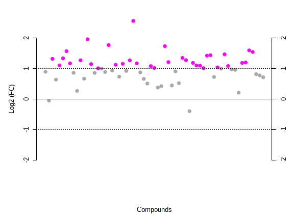

Figure 2. Fold change analysis results.

```r
# Perform fold-change analysis on uploaded data, unpaired
mSet<-FC.Anal(mSet, 2.0, 0, FALSE)

# Plot fold-change analysis
mSet<-PlotFC(mSet, "fc_0_", "png", 72, width=NA)

# To view fold-change
mSet$analSet$fc$fc.log
```

### 2.2 T-Test

MetaboAnalystR supports various options for performing T-test analysis. Users can select the analysis type (*paired*), the group variance (*equal.var*), whether the test is parametric or non-parametric (*nonpar*), and the adjusted p-value (FDR) cut-off (*threshp*).

Note, for a large data set (> 1000 variables), both the paired information and the group variance will be ignored, and the default parameters will be used for t-tests to save computational time. If you choose non-parametric tests (Wilcoxon rank-sum test), the group variance will be ignored.

```r
# Perform T-test (parametric)
mSet<-Ttests.Anal(mSet, nonpar=F, threshp=0.05, paired=FALSE, equal.var=TRUE, "fdr", FALSE)
```

```
## [1] "Performing regular t-tests ...."
## [1] "A total of 53 significant features were found."
```

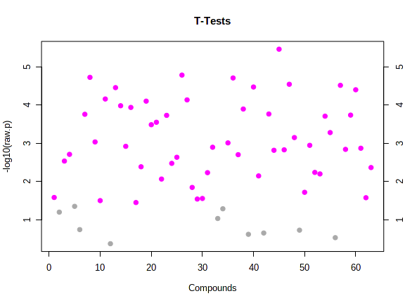

Figure 3. T test analysis results.

|  | X | t.stat | p.value | X.log10.p. | FDR |
| --- | --- | --- | --- | --- | --- |
| 1 | Quinolinate | 5.0149 | 3.4524e-06 | 5.4619 | 0.0002175 |
| 2 | Glucose | 4.6062 | 1.6443e-05 | 4.784 | 0.00027576 |
| 3 | 3-Hydroxyisovalerate | 4.5699 | 1.8835e-05 | 4.725 | 0.00027576 |
| 4 | Leucine | 4.5598 | 1.9555e-05 | 4.7087 | 0.00027576 |
| 5 | Succinate | 4.4571 | 2.8608e-05 | 4.5435 | 0.00027576 |
| 6 | Valine | 4.4397 | 3.0502e-05 | 4.5157 | 0.00027576 |
| 7 | N,N-Dimethylglycine | 4.4123 | 3.3727e-05 | 4.472 | 0.00027576 |
| 8 | Adipate | 4.402 | 3.5017e-05 | 4.4557 | 0.00027576 |
| 9 | myo-Inositol | 4.3669 | 3.9816e-05 | 4.3999 | 0.00027871 |
| 10 | Acetate | 4.2128 | 6.9454e-05 | 4.1583 | 0.00041486 |

[output cut: 43 more lines]

```r
# Plot of the T-test results
mSet<-PlotTT(mSet, imgName = "tt_0_", format = "png", dpi = 72, width=NA)
```

The t test results for MS1 feature table can be used for function analysis.